# Large Language Models

Malo Jan & Luis Sattelmayer

2025-06-18

## Climbing the ladder of abstraction in NLP

- Bag of Words
  - text is represented as a collection of individual words without considering order or context
- Word embeddings
  - dense, fixed-size vectors capturing word semantics
  - e.g. Word2Vec, GloVe, FastText
- Today: **Large Language Models** (LLMs)
  - context-aware embeddings using attention mechanisms
  - e.g. BERT, GPT, Llama & Co

| **Feature** | **Bag-of-Words** | **Static Embeddings** | **Transformers** |
| --- | --- | --- | --- |
| **Core Idea** | Word count representation | Dense, fixed-size vectors capturing word semantics. | Context-aware embeddings using attention mechanisms |
| **Representation** | Sparse vectors (e.g., one-hot encoding, counts) | Dense vectors (e.g., 300 dimensions). | Contextualized vectors generated dynamically |
| **Semantics** | None (words treated independently) | Semantic similarity but context-independent. | Semantic and context-aware understanding |
| **Polysemy Handling** | Cannot distinguish between meanings | Single vector for all senses of a word. | Context-aware disambiguation |
| **Methods** | TF-IDF, word counts, scaling methods | Word2Vec, GloVe, FastText. | LLMs: BERT, GPT, Llama & Co |
| **Weaknesses** | Ignores order and context, sparse | Context-blind, limited for nuanced tasks. | Computationally expensive, requires large data |

## Large Language Models

[figure not shown]

[figure not shown]

## Turing Test

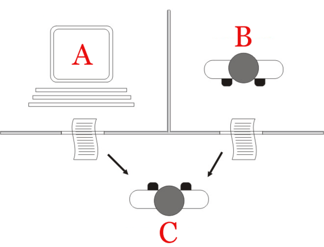

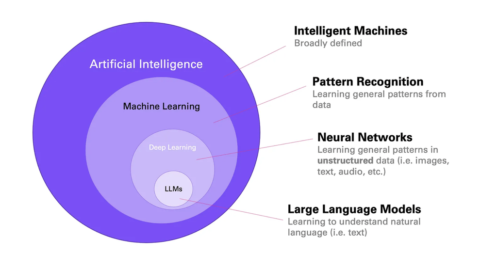

## Neural Networks

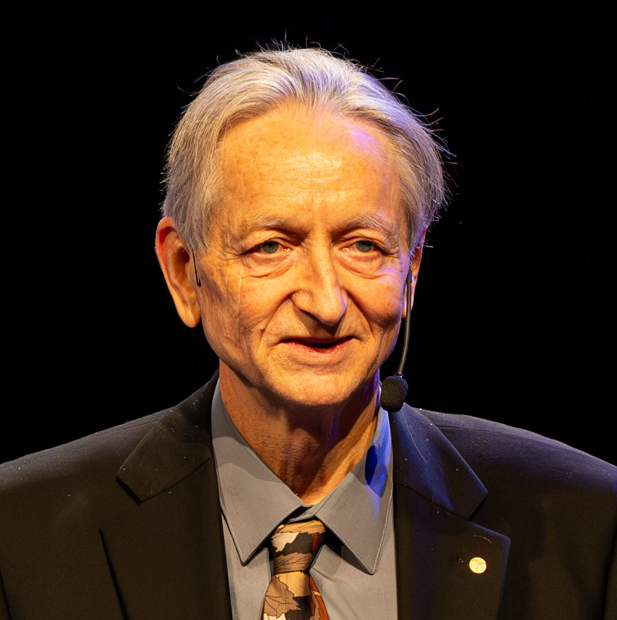

- A profile in the [New Yorker](https://www.newyorker.com/magazine/2023/11/20/geoffrey-hinton-profile-ai) about Geoffrey Hinton

## Neural Networks

- Computational model inspired by the way biological neural networks in the human brain process information
- Designed to recognize patterns, make predictions, or classify data by mimicking the interconnected structure of neurons in the brain

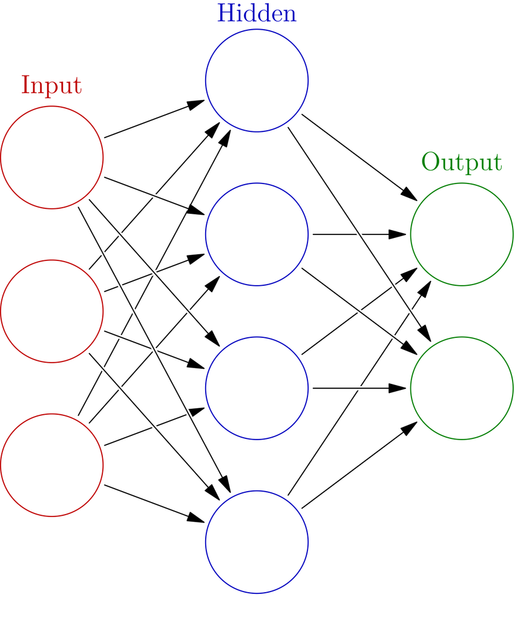

A simple one-layered NN

## Deep Learning

- Oftentimes deep learning & NNs used interchangeably
- Deep refers to the number of layers in the network (i.e. the depth)
- **Weights**: values that define the strength of the connection between two neurons in adjacent layers of a neural network
- **Biases**: parameters that allow the network to shift the activation function up or down
- **Activation Function**: decides whether a neuron should “fire” (pass its signal forward) and how strong that signal should be
  - necessary to introduce *non-linearity* into the network and handle complex patterns in the data

## Transfer learning & fine-tuning

- LLMs are trained on large corpora and thus contain a lot of knowledge about the (written) world
- This knowledge can be *transferred* to other similar and related tasks
- Transfer learning adds a new layer of neural network on top of the pre-trained model
- *Fine-tuning* a pre-trained model on a specific task is often faster and requires less data than training a model from scratch
- The model is fine-tuned on a smaller dataset to adapt to the specifics of the new task
- For fine-tuning, The weights within the model are adjusted to the new task

## Transfer learning

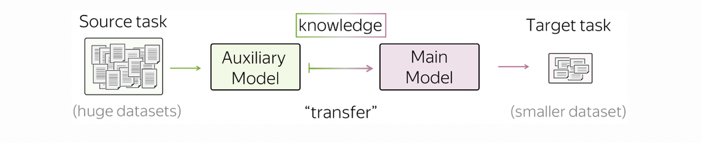

## From pretrained models…

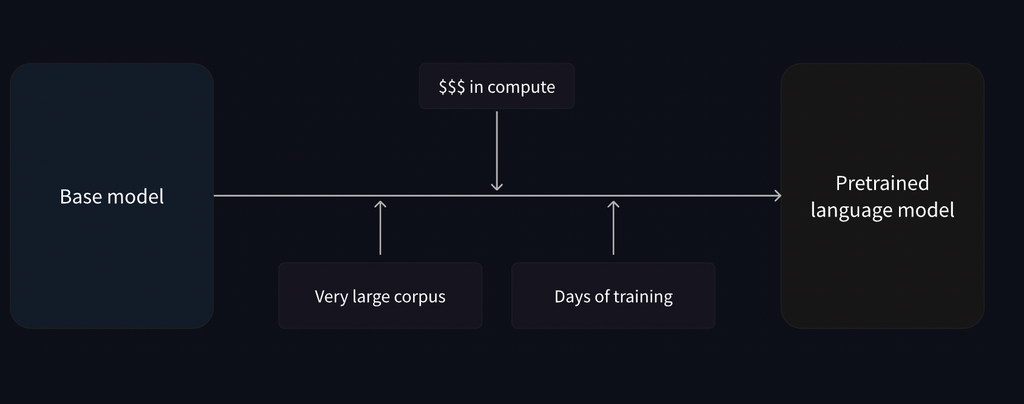

## … to finetuning

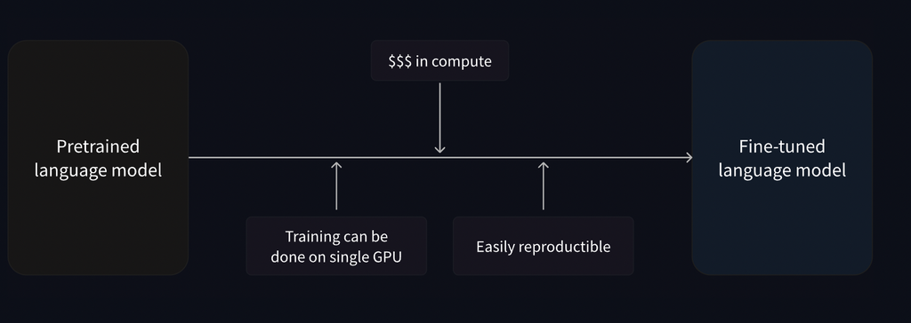

## Finetuning visualized

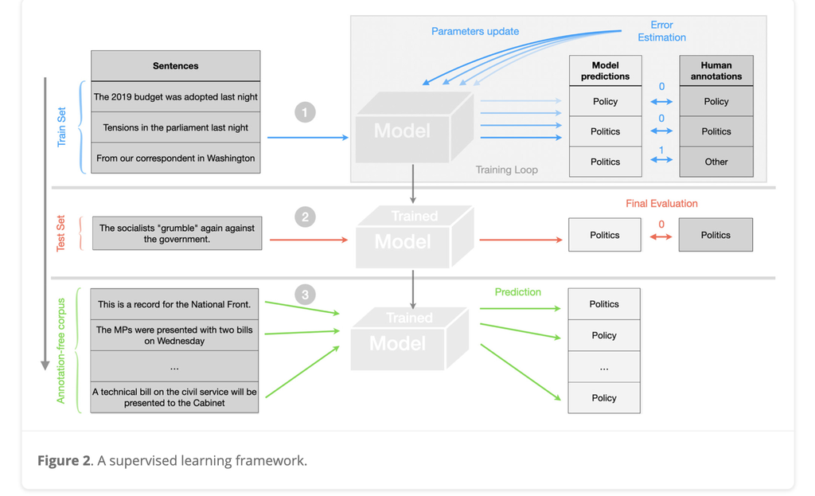

Do, Ollion, and Shen (2024)

## Transformer Architecture

- Also a NN, state of the art since early 2018
- “Attention is all you need” (Vaswani 2017)
- **Attention Mechanism**:
  - allows the model to focus on different parts of the input sequence when predicting the next token
  - crucial for understanding the *context* of a word in a sentence
  - *context size*: the number of tokens the model can consider at once

## Attention Mechanism

- **Self-Attention**:
  - each word in a sentence attends to every other word
  - computes a weighted representation of the input sequence in relation to all other tokens
  - allows the model to capture relationships between words beyond their position in the sequence
- **Multi-Head Attention**:
  - multiple attention mechanisms run in parallel
  - each head learns different aspects of the relationships between words (grammar, semantics, syntax)
  - outputs are concatenated and linearly transformed to produce the final representation
- Attention mechanism directly and efficiently capture long-range dependencies and context –> crucial for understanding dynamic relationships in language

## Attention in Transformers

- For a visualization see [here](https://colab.research.google.com/drive/1hXIQ77A4TYS4y3UthWF-Ci7V7vVUoxmQ?usp=sharing)

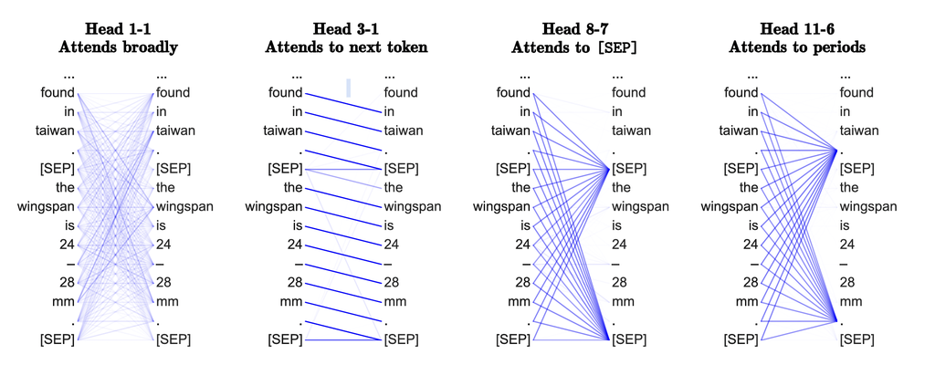

## Transformer Architecture

- **Encoder**:
  - processes the input sequence and generates a contextualized representation of each token
  - consists of multiple layers, each with attention and feedforward neural-network sub-layers
  - captures relationships between words in the input sequence
- **Decoder**:
  - generates the output sequence based on the encoder’s representation
  - also consists of multiple layers, with additional attention mechanisms to focus on the encoder’s output
  - used in tasks like machine translation, text generation/generative AI, etc.
- Think about it like this:
  - Attention: “How does this word relate to the others in the sentence?”
  - Feedforward: “How do I refine the representation of this word, now that I know the context?”

## Transfomer Architecture

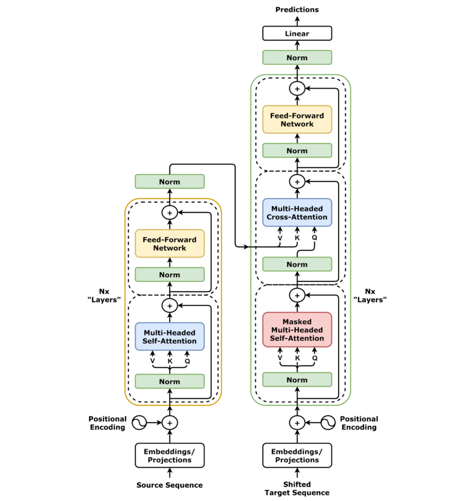

- **Encoder**:
  - processes the input sequence and generates a contextualized representation of each token
  - consists of multiple layers, each with attention and feedforward neural-network sub-layers
  - captures relationships between words in the input sequence

## Training a transformer

- After the model was given huge amounts of raw text, it learns *causal language modeling* and *masked language modeling*

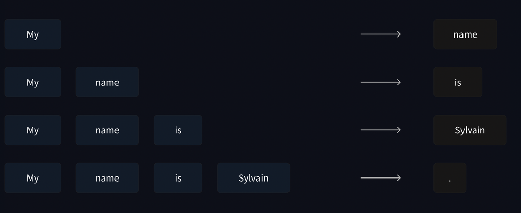

Causally predicting the next word

## Masked Language Modeling

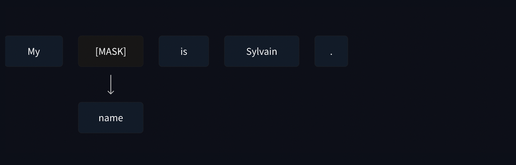

## Token Prediction with Softmax

- After the transformer processes input tokens, it produces a *logit vector* (unnormalized scores but not log-odds like in logistic regressions) for every possible next token in the vocabulary
- These logits are passed through a **softmax** function:

$\text{softmax}(z_i) = \frac{e^{z_i}}{\sum_j e^{z_j}}$

- This turns the logits into a *probability distribution* over the vocabulary
- The model then:
  - Picks the most likely token (*argmax*)
  - Or samples based on the probabilities (e.g. *temperature*)
- Softmax ensures that all output probabilities are positive and sum to 1 — key step for **generative models** (aka Decoder models trained with causal language modeling)

## Softmax

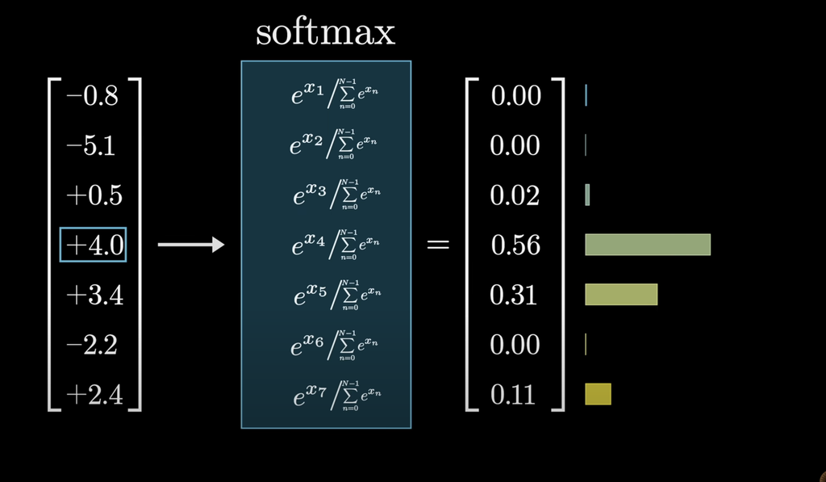

## Softmax

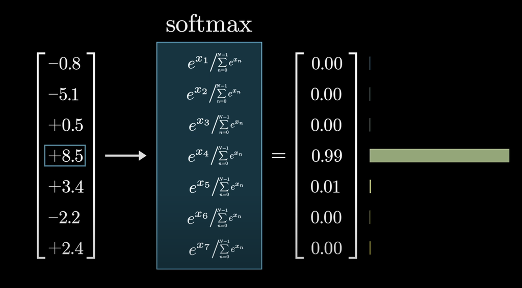

[figure not shown]

## Nvidia stock development

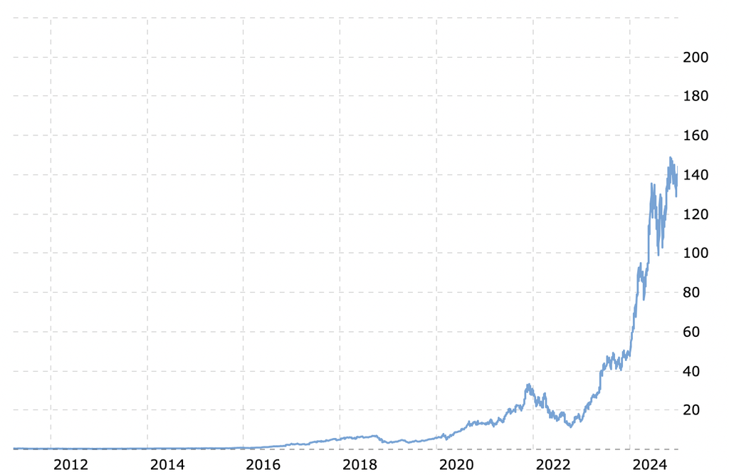

## What is GPU?

- **Graphics Processing Unit**:
  - a specialized processor to render images and video
  - parallel processing capabilities
  - complements the CPU (Central Processing Unit), which excels at sequential tasks
  - optimized for matrix and vector operations; crucial for neural network computations
- **CUDA**: Compute Unified Device Architecture
  - a parallel computing platform and application programming interface model created by NVIDIA
  - allows software developers to use a CUDA-enabled GPU for general purpose processing

## GPU for LLMs

- Massive computation requirements
- Memory bandwidth
- Parallelization
- A task that would take days with a CPU can be done in hours with a GPU
- This does mean that working with LLMs…
  - … requires patience, time, and unfortunately computational ressources

## BERT

- **B**idirectional **E**ncoder **R**epresentations from **T**ransformers
  - masked language model for NLP tasks
  - only uses encoder part of the architecture
  - bi-directional attention, meaning it looks at the context from both the left and right sides of a word
- **RoBERTa**: Removed NSP and trained on larger datasets with more robust techniques
- **DistilBERT**: Smaller and faster version of BERT
- and other variants trained on different languages, tasks, etc

## BERT vs. GPT

|  | **BERT** | **GPT** |
| --- | --- | --- |
| **Type** | Encoder-only | Decoder-only |
| **Training** | Masked Language Modeling (MLM) | Causal Language Modeling (CLM) |
| **Direction** | Bi-directional | Uni-directional |
| **Task Focus** | Language understanding | Language generation |
| **Strength** | Deep sentence/context understanding | Coherent and fluent text generation |

## Evolution of LLMs

[figure not shown]

An outdated evolution tree

## Multilingual Models

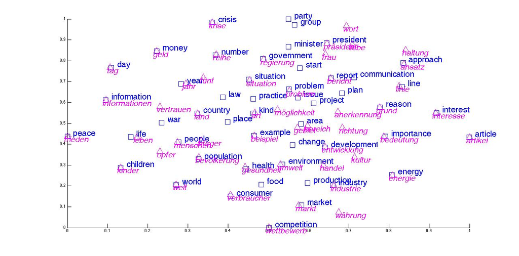

## Multilingual Models

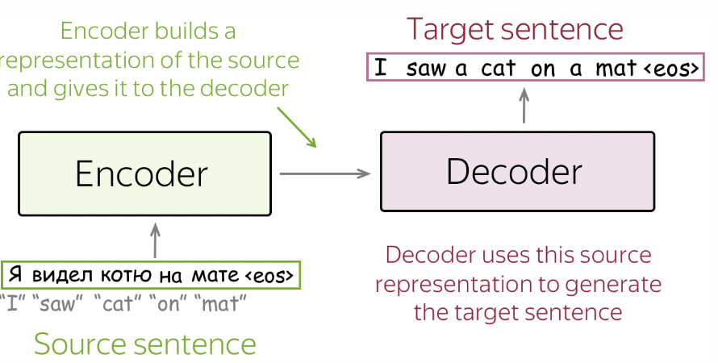

## BERTopic

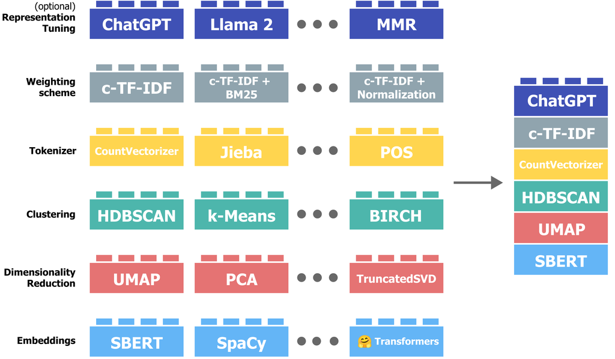

## Modern BERT

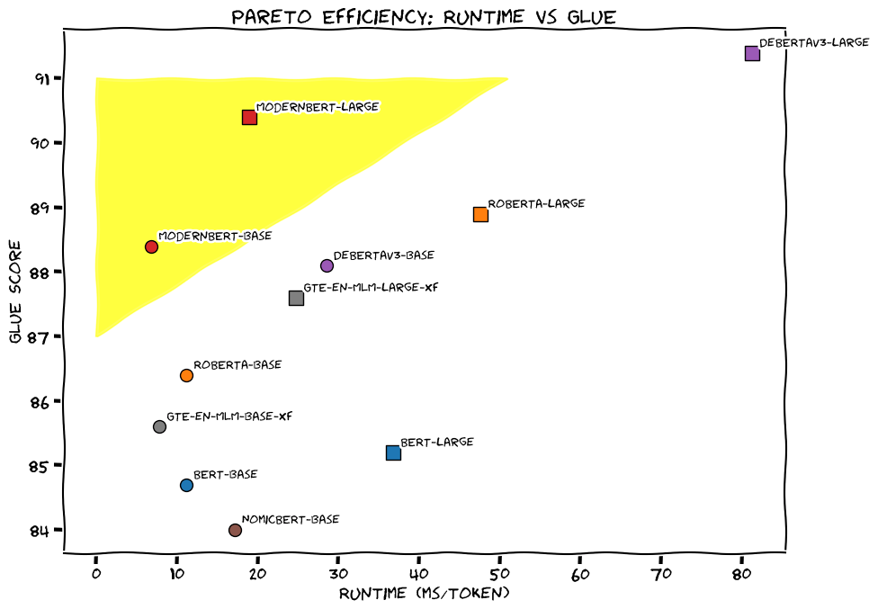

## oLLAMA and open source models

- [oLLAMA](https://ollama.com/) is a platform for running generative LLMs locally
- It allows you to run models like Llama 2, Mistral, and others on your own hardware
- It is open source and can be used to run models *locally* –> no third party involved, great for data protection
- Tends to be done through JSON calls in Python but you can use the [rollama package](https://github.com/JBGruber/rollama?tab=readme-ov-file) by [Johannes B. Gruber](https://www.johannesbgruber.eu/)

## How many shots?

- Weber and Reichardt (2023)
- Zero shot
- One shot
- Few shot
- Chain of Thought

## Issues with LLMs

- Carbon footprint
  - on quantifying ML’s carbon footprint see Lacoste et al. (2019)
- LLMs hardly solve the problem of bias in AI
- GPU dependent (again carbon footprint!)
- Data privacy:
  - without personal GPU, you will have to think a lot about your data and whether it ought to be protected
  - some corpora (e.g. copyrighted data) should not be seen by third parties (Google Colab)
- What is the training data? Where does it come from?
- Private Companies like OpenAI or META
- Hallucination

## Poli-sci examples

- Measure populist frames in text: Bonikowski, Luo, and Stuhler (2022)
- Anti-elite rhetoric: Licht et al. (2024)
- Social groups: Licht and Sczepanksi (2024)

## Bonikowski, Luo, and Stuhler (2022)

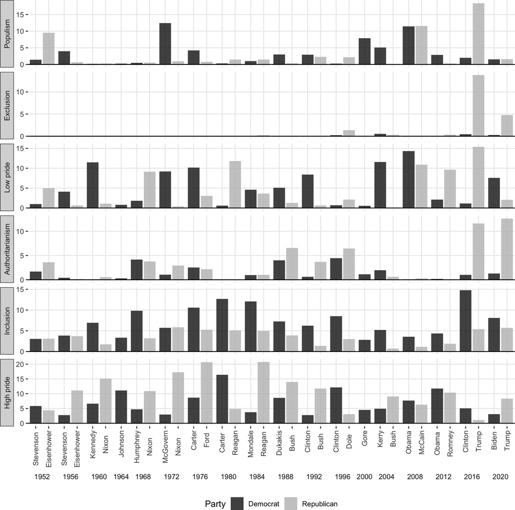

## Bonikowski, Luo, and Stuhler (2022)

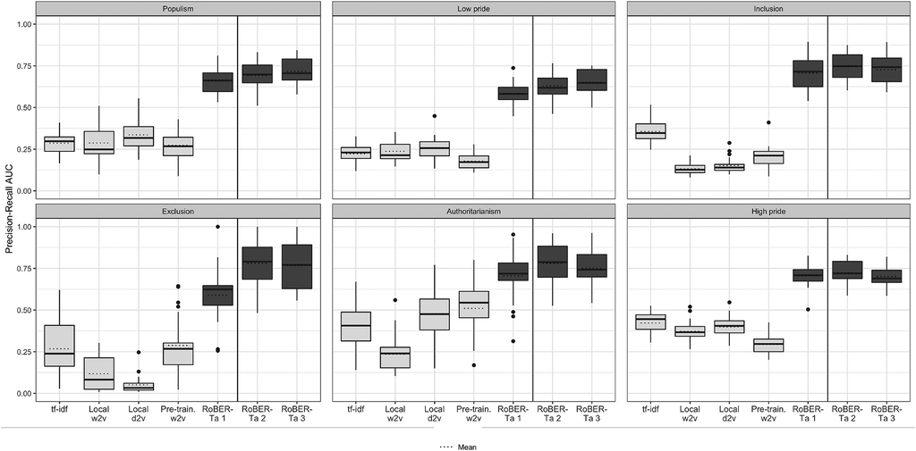

## What other use-cases for Transformers?

- This leaves the realm of textual analysis
- Image generation
  - Dall-E
  - Midjourney
  - Stable diffusion
- speech-to-text
  - [Whisper](https://github.com/openai/whisper)
- Machine translation
  - NMT

## Whisper

- For the GitHub tutorial click [here](https://github.com/openai/whisper)

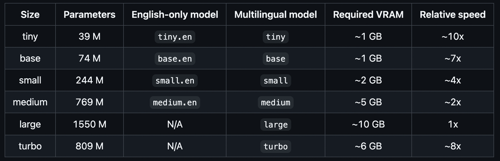

Developed by OpenAI

# Further ressources

- [Lena Voita’s blog on NLP](https://lena-voita.github.io/nlp_course.html)
- Natural Language Inference (NLI)
  - paper by Laurer et al. (2024)
  - GitHub tutorial [here](https://github.com/MoritzLaurer/summer-school-transformers-2023/blob/main/4_tune_bert_nli.ipynb)

## Bibliography

Bonikowski, Bart, Yuchen Luo, and Oscar Stuhler. 2022. “Politics as Usual? Measuring Populism, Nationalism, and Authoritarianism in US Presidential Campaigns (1952–2020) with Neural Language Models.” *Sociological Methods & Research* 51 (4): 1721–87.

Clark, Kevin. 2019. “What Does Bert Look at? An Analysis of Bert’s Attention.” *arXiv Preprint arXiv:1906.04341*.

Do, Salomé, Étienne Ollion, and Rubing Shen. 2024. “The Augmented Social Scientist: Using Sequential Transfer Learning to Annotate Millions of Texts with Human-Level Accuracy.” *Sociological Methods & Research* 53 (3): 1167–1200.

Lacoste, Alexandre, Alexandra Luccioni, Victor Schmidt, and Thomas Dandres. 2019. “Quantifying the Carbon Emissions of Machine Learning.” *arXiv Preprint arXiv:1910.09700*.

Laurer, Moritz, Wouter Van Atteveldt, Andreu Casas, and Kasper Welbers. 2024. “Less Annotating, More Classifying: Addressing the Data Scarcity Issue of Supervised Machine Learning with Deep Transfer Learning and BERT-NLI.” *Political Analysis* 32 (1): 84–100.

Licht, Hauke, Tarik Abou-Chadi, Pablo Barberá, and Whitney Hua. 2024. “Measuring and Understanding Parties’ Anti-Elite Strategies.”

Licht, Hauke, and Ronja Sczepanksi. 2024. “Who Are They Talking about? Detecting Mentions of Social Groups in Political Texts with Supervised Learning.” ECONtribute Discussion Paper.

Vaswani, A. 2017. “Attention Is All You Need.” *Advances in Neural Information Processing Systems*.

Weber, Maximilian, and Merle Reichardt. 2023. “Evaluation Is All You Need. Prompting Generative Large Language Models for Annotation Tasks in the Social Sciences. A Primer Using Open Models.” *arXiv Preprint arXiv:2401.00284*.